# Transparantie peer review

Wouter

2023-06-30

# Transparantie peer review

Transparantie is een belangrijk onderdeel van onderzoek, het zorgt er voor dat onderzoeken makkelijker te controleren en doorgronden zijn. Hiervoor zijn een aantal criteria opgezet Sumner et al. (2020) , zoals te lezen in de tabel hieronder.

|  | Transparency.Criteria | Definition | Response.Type |
| --- | --- | --- | --- |
| 1 | Study Purpose | A concise statement in the introduction of the article, often in the last paragraph, that establishes the reason the research was conducted. Also called the study objective. | Binary |
| 2 | Data Availability Statement | A statement, in an individual section offset from the main body of text, that explains how or if one can access a study?s data. The title of the section may vary, but it must explicitly mention data; … | Binary |
| 3 | Data Location | Where the article?s data can be accessed, either raw or processed. | Found Value |
| 4 | Study Location | Author has stated in the methods section where the study took place or the data?s country/region of origin. | Binary; Found Value |
| 5 | Author Review | The professionalism of the contact information that the author has provided in the manuscript. | Found Value |
| 6 | Ethics Statement | A statement within the manuscript indicating any ethical concerns, including the presence of sensitive data. | Binary |
| 7 | Funding Statement | A statement within the manuscript indicating whether or not the authors received funding for their research. | Binary |
| 8 | Code Availability | Authors have shared access to the most updated code that they used in their study, including code used for analysis. | Binary |

Ik ga hierbij twee onderzoeken beoordelen op deze criteria om te kijken hoe transparant ze zijn. Het eerste onderzoek waar ik dit bij ga doen is: Liu et al. (2023)

Het is een onderzoek naar het effect van radon op het darm microbioom. Het eerste transparantie criterium is zeker behaald, het doel van het onderzoek is duidelijk omschreven in de laatste paar zinnen van de introductie. De data is volgens het data statement aan het einde van het paper te verkrijgen per aanvraag, Dit maakt het snel reproduceren van het onderzoek niet heel handig. hierdoor haalt het het criterium data availability wel maar data location niet. In de materiaal en methode staat waar de muizen verkregen zijn maar niet waar ze gehouden zijn of waar het onderzoek was dus de study location is grotendeels onbekend. Het author review criterium is wel behaald, de auteurs zijn bekend en waar ze werken. Er is geen aparte ethics statement maar er is in de materiaal en methode te lezen dat het onderzoek is geaccepteerd door the Animal Ethical and Welfare Committee of Academy of Military Medical Sciences (IACUC-AMMS, Beijing, China). De funding statement is aanwezig maar niet heel uitgebreid. Er wordt geen code geleverd bij dit onderzoek dus het code availability criterium is niet behaald. In conclusie, Dit onderzoek is goed geschreven maar niet heel erg transparant. Het moeten aanvragen van de data en het missen van de code maakt reproduceren van dit onderzoek erg ingewikkeld.

Voor het tweede onderzoek dat ik ga beoordelen met deze criteria is: Dudel et al. (2020)

Het is een onderzoek dat kijkt naar de case-fatality rate van covid-19 tussen verschillende landen. Het study purpose criterium is wel behaald, maar maar net want het was niet makkelijk te vinden wat men wilt met dit onderzoek. De data availability en data location criteria zijn wel behaald aangezien de data vrij te downloaden is vanuit een link in het paper. De data location staat direct in de metadata van het onderzoek dus deze is ook behaald. Het author review criterium is behaald aangezien er vermeld wordt wie het geschreven heeft en zelfs welke onderdelen ze gedaan hebben. De ethics statement mist maar de funding statement is wel aanwezig dus dat criterium wordt wel gehaald. Als laatste is het criterium voor code availability ook behaald, bij de link om de data te downloaden is ook de code die gebruikt is aanwezig.

Om te laten zien hoe handig het is om transparant te werken Zal ik een deel van de code van het tweede onderzoek zelf uitvoeren om te kijken of het daadwerkelijk werkt, zie de code met het resultaat hieronder.

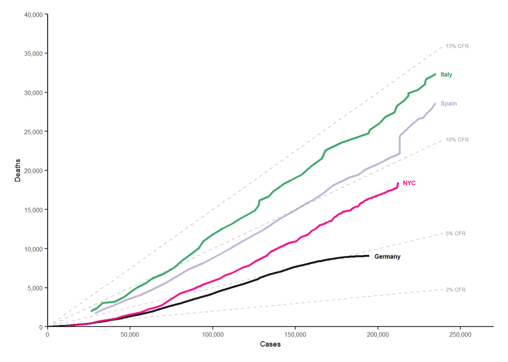

```r
### Monitoring trends and differences in COVID-19 case fatality  ##############
### rates using decomposition methods: A demographic perspective ##############

  ### Last updated: 2020-07-22 11:18:52 CEST

  ### Contact:
  ### riffe@demogr.mpg.de
  ### acosta@demogr.mpg.de
  ### dudel@demogr.mpg.de


### Packages ##################################################################

  library(tidyverse)
  library(ggrepel)
  library(scales)


### Load data #################################################################

  # Load data
  db_gh <- read_csv(here("assignment_1.2", "inputdata.csv")) ### de locatie voor het inlezen van de code moest veranderd worden


### Aggregate data ############################################################

  # Filter date
  db_gh$Date <- as.Date(db_gh$Date,"%d.%m.%y")
  db_gh2 <- db_gh %>% filter(Date<=as.Date("30.06.2020","%d.%m.%y"))

  # Set New York as "country" (easier handling)
  db_gh2$Country[db_gh2$Country=="USA" & db_gh2$Region == "NYC"] <- "NYC"

  # Sum data over age groups
  db_gh2 <- db_gh2 %>%
    filter(!Country %in% c("China","USA","South Korea") & Sex == "b") %>%
    group_by(Country, Code,Date) %>%
    summarise(Cases = sum(Cases),
              Deaths = sum(Deaths))

  # Exclude bolletino
  db_gh2 <- db_gh2 %>%
    filter(str_sub(Code, 1, 5) != "ITbol")

  # Sort by date
  db_gh2 <- db_gh2 %>% group_by(Country) %>% arrange(Date)

  # Smooth reporting issues cases
  for(country in unique(db_gh2$Country)) {

    days <- db_gh2$Date[db_gh2$Country==country]

    for(day in 2:length(days)) {
      current <- db_gh2$Cases[db_gh2$Country==country & db_gh2$Date==days[day]]
      previous <- db_gh2$Cases[db_gh2$Country==country & db_gh2$Date==days[day-1]]

      if(current<previous) db_gh2$Cases[db_gh2$Country==country & db_gh2$Date==days[day]] <- previous

    }

  }

  # Smooth reporting issues deaths
  for(country in unique(db_gh2$Country)) {

    days <- db_gh2$Date[db_gh2$Country==country]

    for(day in 2:length(days)) {
      current <- db_gh2$Deaths[db_gh2$Country==country & db_gh2$Date==days[day]]
      previous <- db_gh2$Deaths[db_gh2$Country==country & db_gh2$Date==days[day-1]]

      if(current<previous) db_gh2$Deaths[db_gh2$Country==country & db_gh2$Date==days[day]] <- previous

    }

  }


### Plot settings #############################################################

  # Set colors
  col_country <- c("Germany" = "black",
                   "Italy" = "#2ca25f",
                   "NYC"="#f0027f",
                   "Spain"="#beaed4",
                   "South Korea"="#fdc086")#,
                   #"USA"="#386cb0")

  cols <- c("black",
            "#2ca25f",
            "#f0027f",
            "#beaed4",
            "#fdc086")#,
            #"#386cb0")


  # Axis
  labs <- db_gh2 %>%
    group_by(Country) %>%
    filter(Cases == max(Cases)) %>%
    mutate(Cases = Cases + 3000)

  # Including all reports
  tx <- 6
  lim_x <- 240000

### Plot ######################################################################

  db_gh2 %>%
    ggplot(aes(Cases, Deaths, col = Country))+
    geom_line(size = 1, alpha = .9)+
    scale_x_continuous(expand = c(0,0), breaks = seq(0, 300000, 50000), limits = c(0, lim_x + 30000), labels = comma)+
    scale_y_continuous(expand = c(0,0), breaks = seq(0, 40000, 5000), limits = c(0, 40000), labels = comma)+
    annotate("segment", x = 0, y = 0, xend = lim_x, yend = lim_x * .02, colour = "grey40", size = .5, alpha = .3, linetype = 2)+
    annotate("segment", x = 0, y = 0, xend = lim_x, yend = lim_x * .05, colour = "grey40", size = .5, alpha = .3, linetype = 2)+
    annotate("segment", x = 0, y = 0, xend = lim_x, yend = lim_x * .10, colour = "grey40", size = .5, alpha = .3, linetype = 2)+
    annotate("segment", x = 0, y = 0, xend = lim_x, yend = lim_x * .15, colour = "grey40", size = .5, alpha = .3, linetype = 2)+
    annotate("text", label = "2% CFR", x = lim_x + 1000, y = lim_x * .02,
             color="grey30", size = tx * .3, alpha = .6, hjust = 0, lineheight = .8) +
    annotate("text", label = "5% CFR", x = lim_x + 1000, y = lim_x * .05,
             color="grey30", size = tx * .3, alpha = .6, hjust = 0, lineheight = .8) +
    annotate("text", label = "10% CFR", x = lim_x + 1000, y = lim_x * .10,
             color="grey30", size = tx * .3, alpha = .6, hjust = 0, lineheight = .8) +
    annotate("text", label = "15% CFR", x = lim_x + 1000, y = lim_x * .15,
             color="grey30", size = tx * .3, alpha = .6, hjust = 0, lineheight = .8) +
    scale_colour_manual(values = cols)+
    geom_text(data = labs, aes(Cases, Deaths, label = Country),
              size = tx * .35, hjust = 0, fontface = "bold") +
    theme_classic()+
    labs(x = "Cases",
         y = "Deaths")+
    theme(
      panel.grid.minor = element_blank(),
      legend.position = "none",
      plot.margin = margin(5,5,5,5,"mm"),
      axis.text.x = element_text(size = tx),
      axis.text.y = element_text(size = tx),
      axis.title.x = element_text(size = tx + 1),
      axis.title.y = element_text(size = tx + 1)
    )
```

```r
  # Save
  # ggsave("Output/Fig_1.jpg", width = 4, height = 3, dpi = 600) ### ik heb de ggsave gecomment zodat dit niet als aparte afbeelding opgeslagen wordt want dat is niet nodig voor dit voorbeeld.
```

Zoals te zien hierboven heeft de code gewerkt. Ik heb twee kleine aanpassingen gedaan, namelijk: de data voor het inladen stond op een andere plek dus die heb ik even aangepast en ik heb de ggsave uit gecomment zodat deze niet telkens probeert om een afbeelding op te slaan dat je de code runt.

Uit het resultaat van de code is te zien dat deze code heel netjes en leesbaar is geschreven en zonder ingrijpende handelingen hetzelfde resultaat geeft als in het paper is laten zien. Ik zou de leesbaarheid van de code op een schaal van 1 (heel slecht) tot 5 (erg goed) een 5 geven aangezien het duidelijk leesbaar is met comments en tussenkopjes. Ik zou de reprodureerbaarheid van dit onderzoek op een schaal van 1 (heel slecht) tot 5 (erg goed) een 5 geven aangezien de code met een paar kleine aanpassingen precies hetzelfde resultaat geeft als gepresenteert in het paper.

## Bibliografie:

Dudel, Christian, Tim Riffe, Enrique Acosta, Alyson Van Raalte, Cosmo Strozza, and Mikko Myrskylä. 2020. “Monitoring Trends and Differences in COVID-19 Case-Fatality Rates Using Decomposition Methods: Contributions of Age Structure and Age-Specific Fatality.” Edited by Bruno Masquelier. *PLOS ONE* 15 (9): e0238904. https://doi.org/10.1371/journal.pone.0238904.

Liu, Huimeng, Meiyu Wang, Guangrui Chen, Huiyu Zhou, Jiahui Dong, Lei Yang, Tong Li, et al. 2023. “Effects of Radon Exposure on Gut Microbiota and Its Metabolites Short-Chain Fatty Acids in Mice.” *Toxicology* 486 (March): 153449. https://doi.org/10.1016/j.tox.2023.153449.

Sumner, Josh, Leah Haynes, Sarah Nathan, Cynthia Hudson-Vitale, and Leslie D. McIntosh. 2020. “Reproducibility and Reporting Practices in COVID-19 Preprint Manuscripts.” Preprint. Health Informatics. https://doi.org/10.1101/2020.03.24.20042796.